# Tissue-Class Segmentation

## Overall Pipeline

## Image segmentation

- We are often interested in subdividing or segmenting the brain into meaningful biological regions of interest (ROIs) for an analysis.
- Examples: tissue segmentation, segmentation of gray matter structures, segmentation of pathology (MS lesions, tumors, …)
- We will perform 3-class tissue segmentation in R using `fslr` and `ANTsR`:
  - Cerebrospinal fluid (CSF)
  - Gray Matter (GM)
  - White Matter (WM)

## Loading Data

- Let's read in the training T1 and brain mask for subject 05 (not 01!).

```r
library(ms.lesion)
library(neurobase)
all_files = get_image_filenames_list_by_subject(
  group = "training",
  type = "coregistered")
files = all_files$training05 # NOT training subject 1!
t1 = readnii(files["MPRAGE"])
rt1 = robust_window(t1)
mask = readnii(files["Brain_Mask"])
```

## Tissue Segmentation: Large Outliers

- Many tissue class segmentations are based on k-means clustering.
- These methods can be skewed by large outliers.

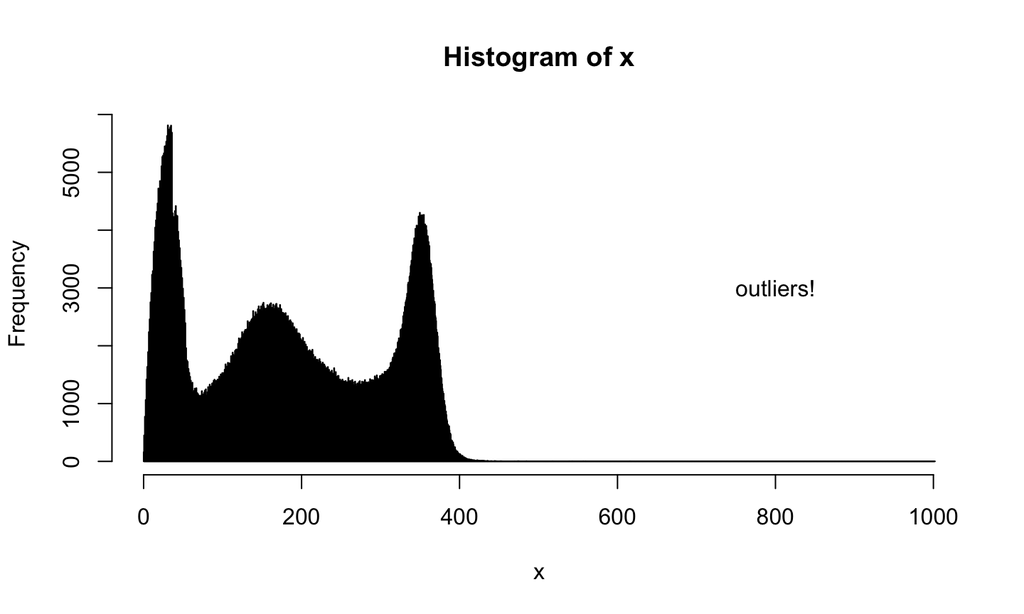

```r
hist(t1, mask = mask, breaks = 2000); text(x = 800, y = 3000, "outliers!")
```

## Where are the outliers?

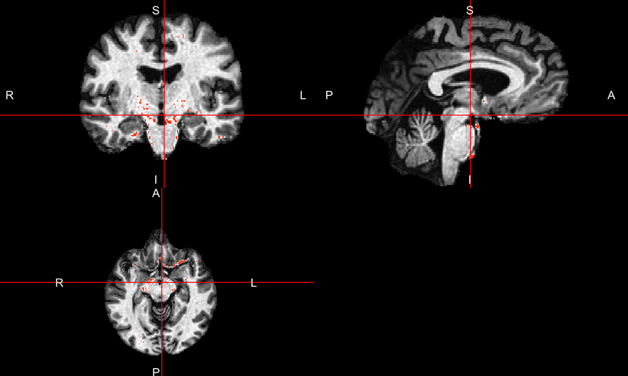

```r
ortho2(rt1, t1 > 400, xyz = xyz(t1 > 400)) # xyz - cog of a region
```

## Tissue Segmentation using FSL FAST

- FAST is based on a hidden Markov random field model and an Expectation-Maximization algorithm (Zhang, Brady, and Smith 2001).
- It jointly produces a bias field corrected image and a probabilistic tissue segmentation.
- More robust to noise and outliers than finite mixture model-based methods that do not incorporate spatial information.

The `fslr` function `fast` calls fast from FSL. The `--nobias` option tells FSL to not perform inhomogeneity correction (N4 already performed in `ANTsR`).

```r
t1file = files["MPRAGE"]
t1fast = fast(t1,
              outfile = paste0(nii.stub(t1file), "_FAST"),
              opts = "--nobias")
```

## FAST Results

FAST assumes three tissue classes and produces an image with the three labels, ordered by increasing within-class mean intensities. In a T1 image, this results in:

- Level 1: CSF
- Level 2: Gray Matter
- Level 3: White Matter

## FAST: White Matter

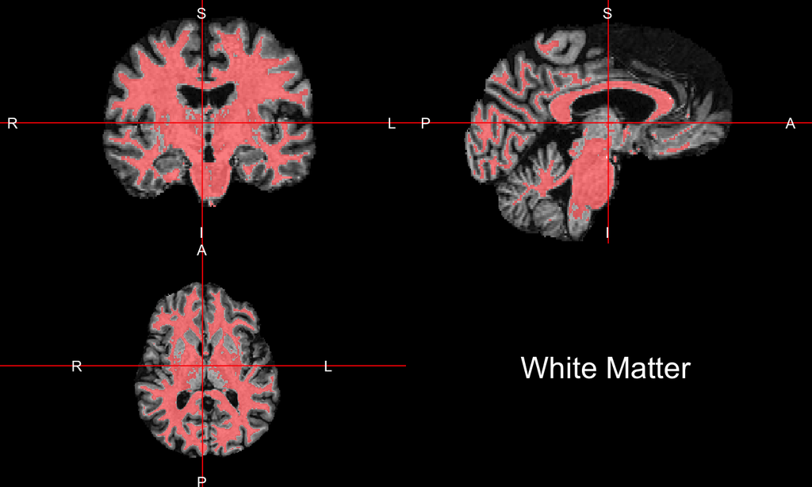

```r
ortho2(rt1, t1fast == 3, col.y = alpha("red", 0.5), text = "White Matter")
```

## FAST: Gray Matter

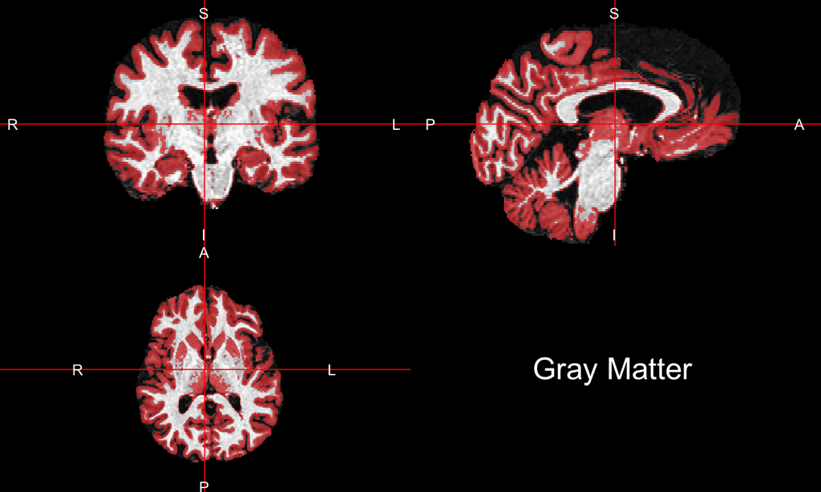

```r
ortho2(rt1, t1fast == 2, col.y = alpha("red", 0.5), text = "Gray Matter")
```

## FAST: CSF

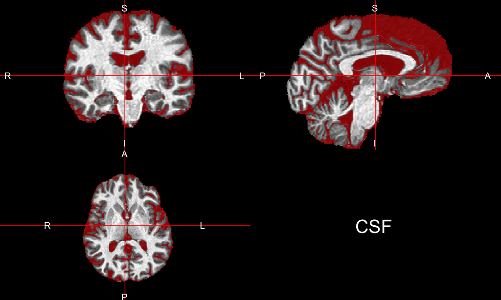

```r
ortho2(rt1, t1fast == 1, col.y = alpha("red", 0.5), text = "CSF")
```

## Removing large values: Is there an effect?

```r
robust_fast = fast(rt1, # the robust_window(t1)
              outfile = paste0(nii.stub(t1file), "_FAST"),
              opts = "--nobias")
```

## FAST with Window: White Matter

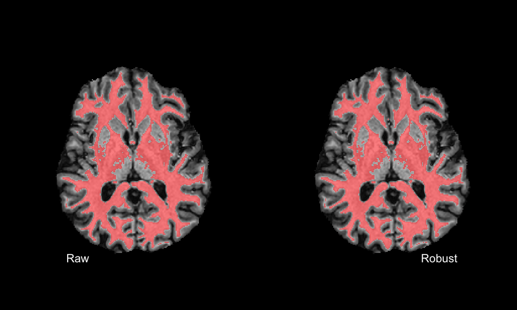

## FAST with Window: Gray Matter

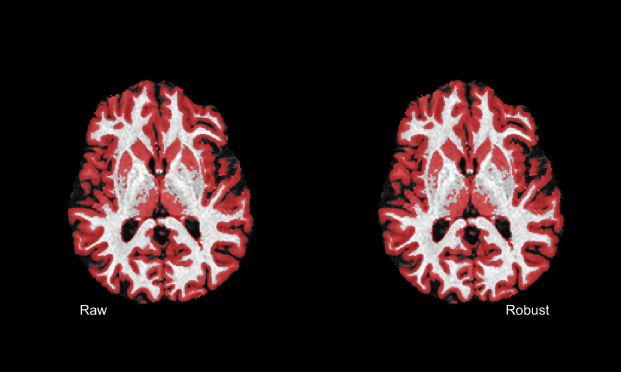

## FAST with Window: CSF

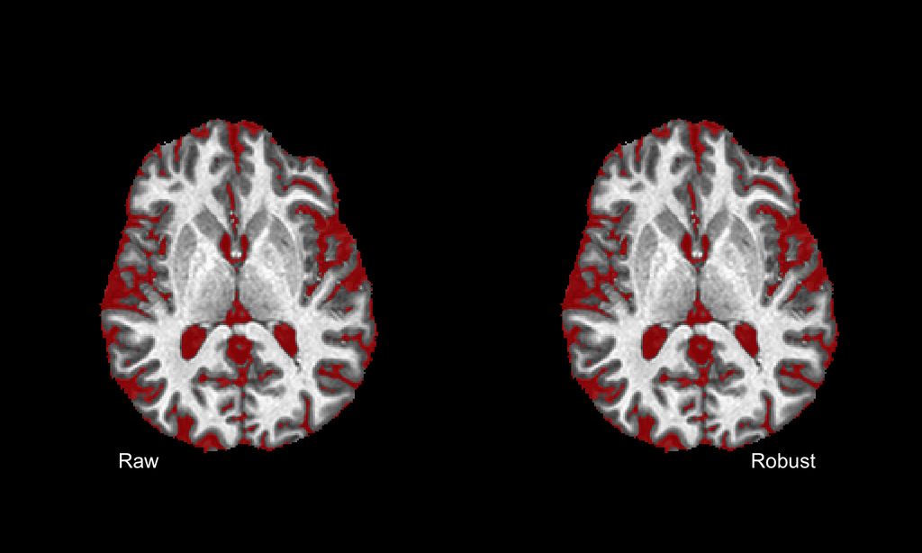

## FAST Results

- Overall the results look good
  - Not much difference after dampening outliers using `robust_window`

## Tissue Segmentation using ANTsR, extrantsr

- Uses Atropos (Avants et al. 2011)
  - 3D K-means clustering + a Markov random field
- The `extrantsr::otropos` function works with `nifti` objects
  - calls `ANTsR::atropos` function

```r
t1_otropos = otropos(a = t1, x = mask) # using original data
t1seg = t1_otropos$segmentation
```

## Atropos: White Matter

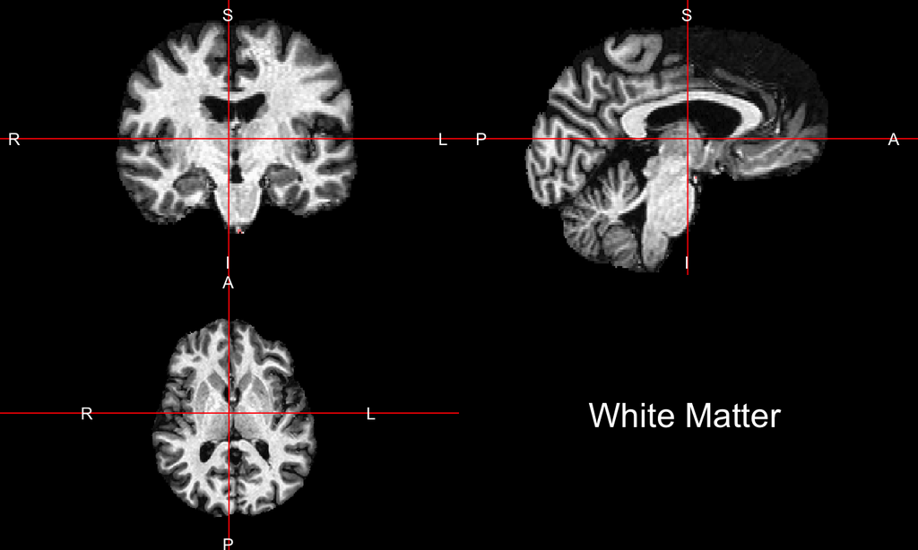

```r
ortho2(rt1, t1seg == 3, col.y = alpha("red", 0.5), text = "White Matter")
```

## Atropos: Gray Matter

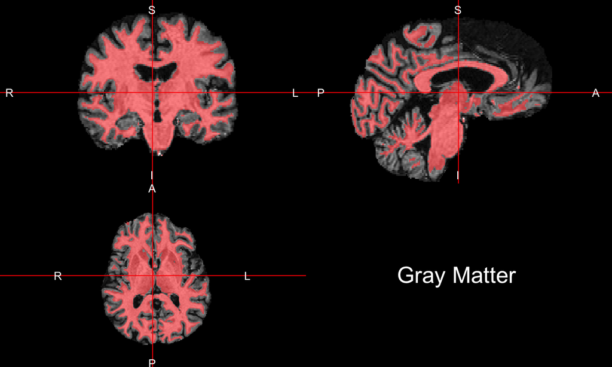

```r
ortho2(rt1, t1seg == 2, col.y = alpha("red", 0.5), text = "Gray Matter")
```

## Atropos: CSF

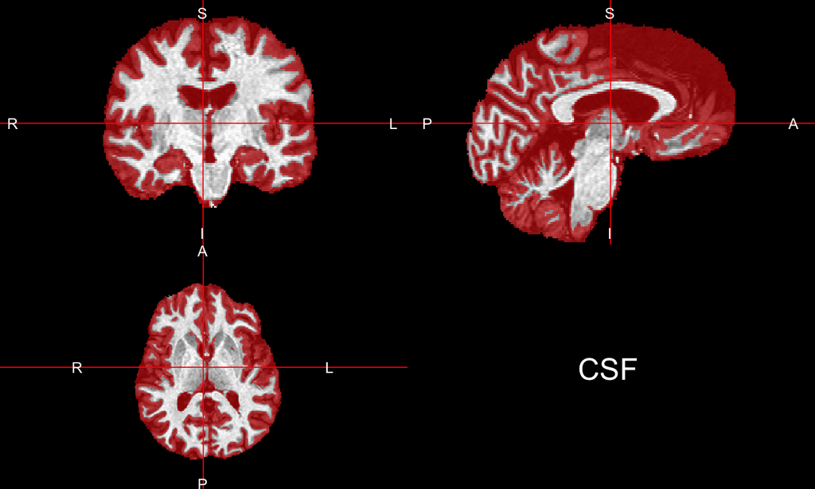

```r
ortho2(rt1, t1seg == 1, col.y = alpha("red", 0.5), text = "CSF")
```

## Default Atropos Results

- Overall the results do not look good
  - The k-means clustering is affected by large outliers
- We will try using `robust_window`

## Atropos using Windowing

```r
robust_t1_otropos = otropos(a = rt1, x = mask) # using robust
robust_t1seg = robust_t1_otropos$segmentation
```

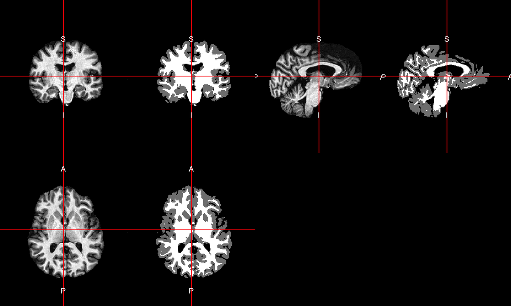

```r
double_ortho(rt1, robust_t1seg)
```

## Atropos with Window: White Matter

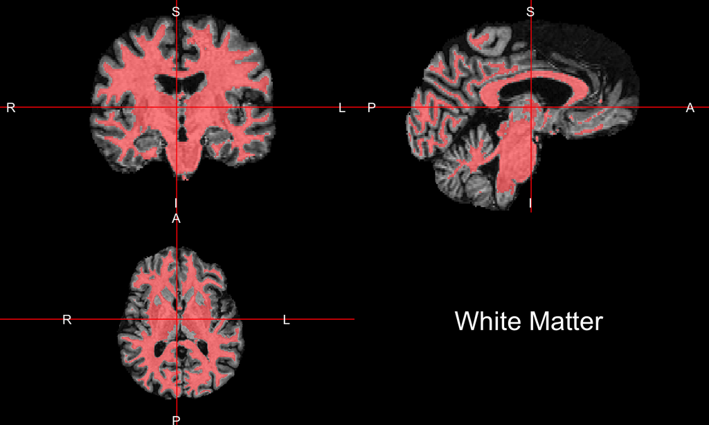

```r
ortho2(rt1, robust_t1seg == 3, col.y = alpha("red", 0.5), text = "White Matter")
```

## Atropos with Window: Gray Matter

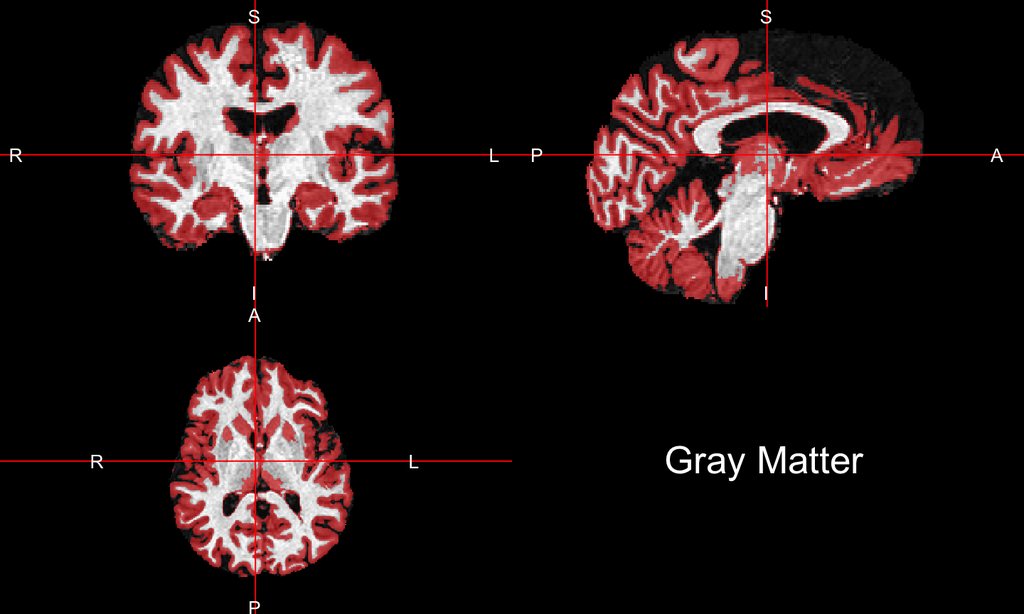

```r
ortho2(rt1, robust_t1seg == 2, col.y = alpha("red", 0.5), text = "Gray Matter")
```

## Atropos with Window: CSF

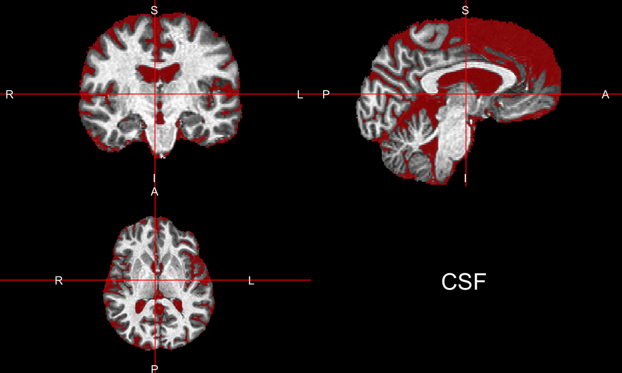

```r
ortho2(rt1, robust_t1seg == 1, col.y = alpha("red", 0.5), text = "CSF")
```

## Atropos with Window Results

- Overall the results look like they reasonably separate the classes
  - No ground truth
- Winsorizing large outliers aided the k-means clustering
  - Results much better than running Atropos on the raw data

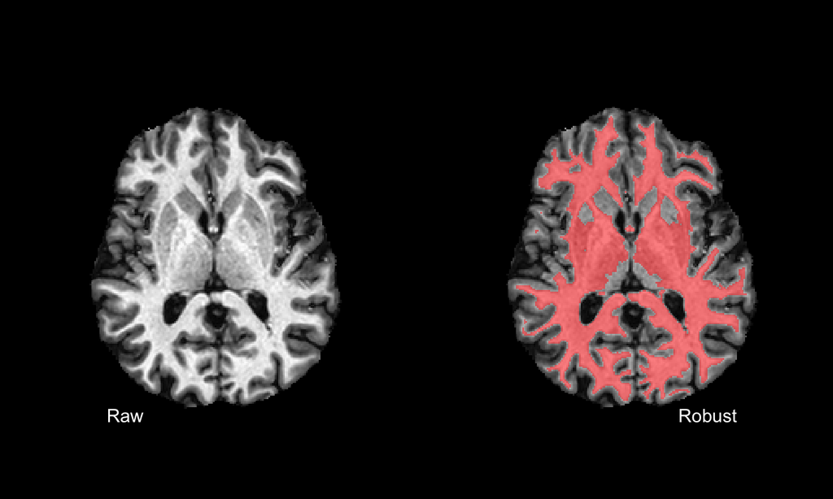

## Atropos WM vs. FAST WM

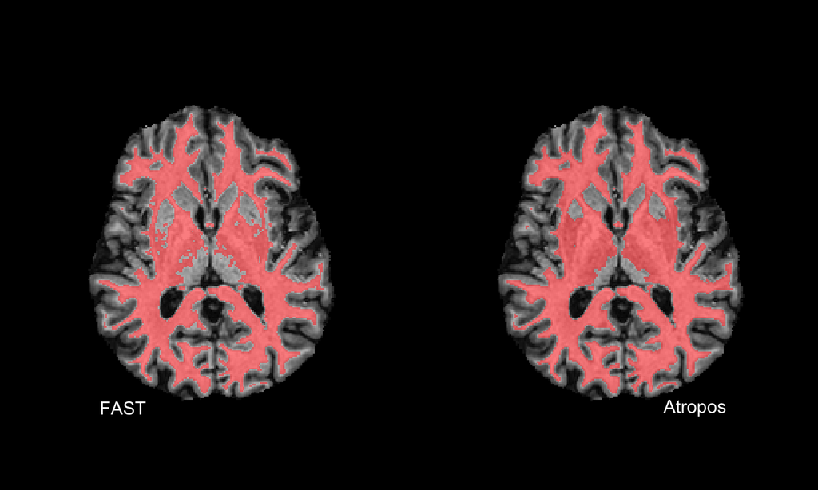

## Estimating the Volume of Each Class

We can create a table which will count the number of voxels in each category:

```r
tab_fsl = table(robust_fast[ robust_fast != 0])
tab_ants = table(robust_t1seg[ robust_t1seg != 0])
names(tab_fsl) = names(tab_ants) = c("CSF", "GM", "WM")
tab_fsl
```

```
   CSF     GM     WM
363382 690041 472123
```

```r
tab_ants
```

```
   CSF     GM     WM
299850 702052 523804
```

## Estimating the Volume of Each Class

By multiplying by the voxel resolution (in cubic centimeters) using the `voxres` function, we can get volumes

```r
vres = oro.nifti::voxres(t1, units = "cm")
print(vres)
```

```
[1] 0.0008023755
```

```r
vol_fsl = tab_fsl * vres
vol_fsl
```

```
     CSF       GM       WM
291.5688 553.6720 378.8199
```

```r
vol_ants = tab_ants * vres
vol_ants
```

```
     CSF       GM       WM
240.5923 563.3093 420.2875
```

## Website

http://johnmuschelli.com/imaging_in_r

## References

Avants, Brian B, Nicholas J Tustison, Jue Wu, Philip A Cook, and James C Gee. 2011. “An Open Source Multivariate Framework for N-Tissue Segmentation with Evaluation on Public Data.” *Neuroinformatics* 9 (4). Springer: 381–400.

Zhang, Yongyue, Michael Brady, and Stephen Smith. 2001. “Segmentation of Brain MR Images Through a Hidden Markov Random Field Model and the Expectation-Maximization Algorithm.” *Medical Imaging, IEEE Transactions on* 20 (1): 45–57. http://ieeexplore.ieee.org/xpls/abs_all.jsp?arnumber=906424.